# RNAseq_QC

Matthew Taliaferro

6/14/2020

# Overview

Cells were grown in generic differentiation-promoting media (LIF<sup>-</sup>) for 8 days until aggreates were dissociated and replated in neuronal differentiation media. This day of replating was designated as *in vitro* day 0 (DIV0). The timepoints taken before this replating therefore happened at “negative” times (DIV-8 and DIV-4). Because naming files with dashes or minus signs can cause problems, these samples are referred to as DIVminus8 and DIVminus4. Following the replating, samples were taken at days 1, 7, 16, 21, and 28 (DIV1, DIV7, DIV16, DIV21, and DIV28).

Today we will focus on some Quality Control steps that are good ideas to do for every RNAseq dataset you encounter, whether produced by yourself or someone else.

# Quantification of reads with salmon

We recently learned about the RNAseq quantification tool [salmon](https://combine-lab.github.io/salmon/). We won’t rehash the details here about how salmon works. For our purposes, we just need to know that salmon reads in a fastq file of sequencing reads and a fasta file of transcript sequences to be quantified. Let’s take a look at this fasta file of transcripts:

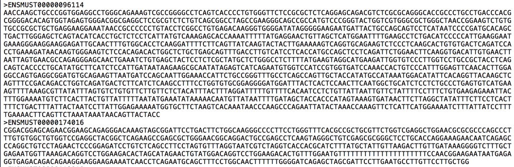

Looks like we have ensembl transcript IDs, which is a good idea. I can tell because they start with ‘ENS’. Using ensembl IDs as transcript names will allow us to later collate transcript expression levels into gene expression levels using a database that relates transcripts and genes. More on that later.

### Making a transcriptome index

The first step in quantifying these transcripts is to make an index from them. This is done as follows:

```
salmon index -t <transcripts.fa> -i <transcripts.idx> --type quasi -k <k>
```

Here, transcripts.fa is a path to our fasta file, transcripts.idx is the name of the index that will be created, and k is the length of the kmers that will be used in the hash table related kmers and transcripts. k is the length of the minimum accepted match for a kmer in a read and a kmer in a transcript. Longer kmers (higher values of k) will therefore be more stringent, and lowering k may improve mapping sensitivity at the cost of some specificity. You may also see here how read lengths can influence what value for k you should choose.

Consider an experiment where we had 25 nt reads (this was true wayyyyyy back in the old, dark days of high-throughput sequencing). What’s going to happen if I quantify these reads using an index where the kmer size was set to 29? Well, nothing will align. The index has represented the transcriptome in 29 nt chunks. However, no read will match to these 29mers because there are no 29mers in these reads! *As a general rule of thumb, for reads 75 nt and longer (which is the bulk of the data produced nowadays), a good value for k that maximizes both specificity and sensitivity is 31*. However, datasets that you may retrieve from the internet, particularly older ones, may have shorter read lengths, so keep this is mind when defining k.

### Quantifying reads against your index

Once we have our index, we can quantify transcripts in the index using reads from our fastq files.

```
salmon quant --libType A -p 8 --seqBias --gcBias --validateMappings -1 <forwardreads.fastq> -2 <reversereads.fastq> -o <outputname> --index <transcripts.idx>
```

In this command, our forward and reverse read fastq files are supplied to -1 and -2, respectively. If the experiment produced single end reads, -2 is omitted. <transcripts.idx> is the path to the index produced in the previous step. I’m not going to go through the rest of the flags used here, but their meanings as well as other options can be found [here](https://salmon.readthedocs.io/en/latest/salmon.html#using-salmon)

### Salmon outputs

Let’s take a look at what salmon spits out. The first file we will look at is a log that is found at **/logs/salmon_quant.log**. This file contains info about the quantification, but there’s one line of this file in particular that we are interested in. It lets us know how many of the reads in the fastq file that salmon found a home for in the transcriptome fasta.

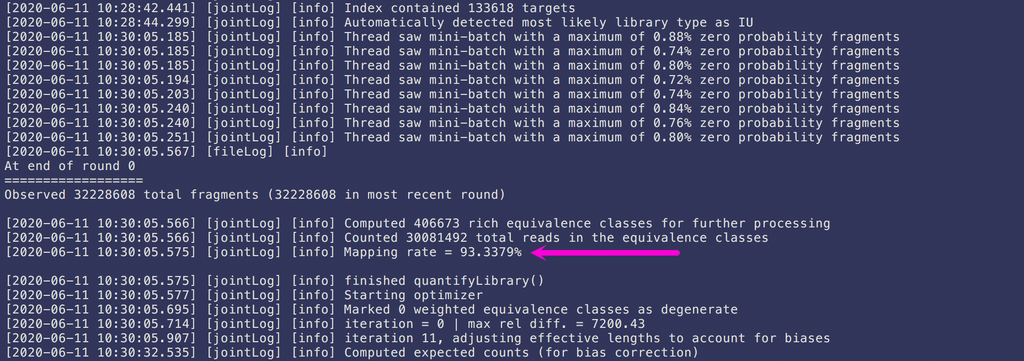

There are a lot of lines in this file, but really only one that we are interested in. We want the one that tells us the “Mapping rate.” How could we easily and efficiently look at the mapping rates of all our samples? **Grep!**

```bash
#Get the mapping rates for all samples
#In each log file, the line that we are interested in contains the string 'Mapping ' (notice the space)
grep 'Mapping ' ../data/salmonouts/*/logs/salmon_quant.log
```

Another way to do this is to use a tool called [MultiQC](https://multiqc.info/). MultiQC is a python package that, given a place to look, will scan for the log files produced by many common sequence analysis programs, including salmon. It will output an html file that is nice for inspecting sample stats and quickly identifying outlier samples.

```bash
multiqc data/salmonouts/*
```

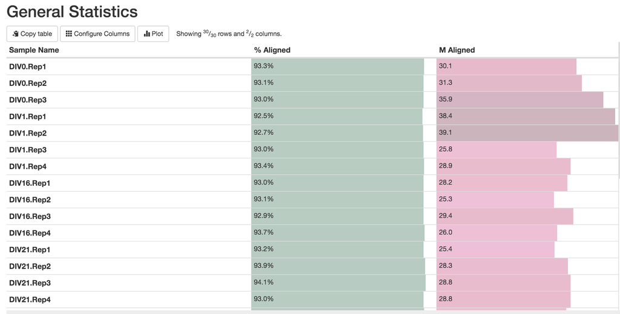

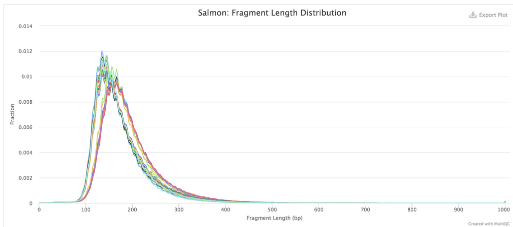

# Moving from transcript quantifications to gene quantifications

As we discussed, salmon quantifies *transcripts*, not *genes*. However, genes are made up of transcripts, so we can calculate gene expression values from transcript expression values if we knew which transcripts belonged to which genes. We can get this information through `biomaRt`.

`biomaRt` has many tables that relate genes, transcripts, and other useful data include gene biotypes and gene ontology categories, even across species. Let’s use it here to get a table of genes and transcripts for the mouse genome.

```r
#Load biomaRt
library(biomaRt)

#First we need to define a 'mart' to use.  There are a handful of them that you can see here:
listMarts(mart = NULL, host = 'uswest.ensembl.org')
```

```
##                biomart                version
## 1 ENSEMBL_MART_ENSEMBL      Ensembl Genes 101
## 2   ENSEMBL_MART_MOUSE      Mouse strains 101
## 3     ENSEMBL_MART_SNP  Ensembl Variation 101
## 4 ENSEMBL_MART_FUNCGEN Ensembl Regulation 101
```

I encourage you to see what is in each mart, but for now we are only going to use ENSEMBL_MART_ENSEMBL This may take a minute or two to connect.

```r
mart <- biomaRt::useMart("ENSEMBL_MART_ENSEMBL", host='uswest.ensembl.org')
```

Alright, we’ve chosen our mart. What datasets are available in this mart?

```r
datasets <- listDatasets(mart)
kable(datasets)
```

| dataset | description | version |
| --- | --- | --- |
| acalliptera_gene_ensembl | Eastern happy genes (fAstCal1.2) | fAstCal1.2 |
| acarolinensis_gene_ensembl | Anole lizard genes (AnoCar2.0) | AnoCar2.0 |
| acchrysaetos_gene_ensembl | Golden eagle genes (bAquChr1.2) | bAquChr1.2 |
| acitrinellus_gene_ensembl | Midas cichlid genes (Midas_v5) | Midas_v5 |
| amelanoleuca_gene_ensembl | Panda genes (ailMel1) | ailMel1 |
| amexicanus_gene_ensembl | Mexican tetra genes (Astyanax_mexicanus-2.0) | Astyanax_mexicanus-2.0 |
| ampachon_gene_ensembl | Pachon cavefish genes (Astyanax_mexicanus-1.0.2) | Astyanax_mexicanus-1.0.2 |
| anancymaae_gene_ensembl | Ma’s night monkey genes (Anan_2.0) | Anan_2.0 |
| aplatyrhynchos_gene_ensembl | Mallard genes (ASM874695v1) | ASM874695v1 |
| applatyrhynchos_gene_ensembl | Duck genes (CAU_duck1.0) | CAU_duck1.0 |
| atestudineus_gene_ensembl | Climbing perch genes (fAnaTes1.1) | fAnaTes1.1 |
| bbbison_gene_ensembl | American bison genes (Bison_UMD1.0) | Bison_UMD1.0 |
| bgrunniens_gene_ensembl | Domestic yak genes (LU_Bosgru_v3.0) | LU_Bosgru_v3.0 |
| bihybrid_gene_ensembl | Hybrid - Bos Indicus genes (UOA_Brahman_1) | UOA_Brahman_1 |
| bmutus_gene_ensembl | Wild yak genes (BosGru_v2.0) | BosGru_v2.0 |
| bsplendens_gene_ensembl | Siamese fighting fish genes (fBetSpl5.2) | fBetSpl5.2 |
| btaurus_gene_ensembl | Cow genes (ARS-UCD1.2) | ARS-UCD1.2 |
| bthybrid_gene_ensembl | Hybrid - Bos Taurus genes (UOA_Angus_1) | UOA_Angus_1 |
| cabingdonii_gene_ensembl | Abingdon island giant tortoise genes (ASM359739v1) | ASM359739v1 |
| capalliatus_gene_ensembl | Angola colobus genes (Cang.pa_1.0) | Cang.pa_1.0 |
| caperea_gene_ensembl | Brazilian guinea pig genes (CavAp1.0) | CavAp1.0 |
| catys_gene_ensembl | Sooty mangabey genes (Caty_1.0) | Caty_1.0 |
| ccanadensis_gene_ensembl | American beaver genes (C.can_genome_v1.0) | C.can_genome_v1.0 |
| ccapucinus_gene_ensembl | Capuchin genes (Cebus_imitator-1.0) | Cebus_imitator-1.0 |
| ccarpio_gene_ensembl | Common carp genes (common_carp_genome) | common_carp_genome |
| cdromedarius_gene_ensembl | Arabian camel genes (CamDro2) | CamDro2 |
| celegans_gene_ensembl | Caenorhabditis elegans genes (WBcel235) | WBcel235 |
| cgchok1gshd_gene_ensembl | Chinese hamster CHOK1GS genes (CHOK1GS_HDv1) | CHOK1GS_HDv1 |
| cgcrigri_gene_ensembl | Chinese hamster CriGri genes (CriGri_1.0) | CriGri_1.0 |
| cgobio_gene_ensembl | Channel bull blenny genes (fCotGob3.1) | fCotGob3.1 |

[output cut: 173 more lines]

Alot of stuff for a lot of species! Perhaps we want to limit it to see which ones are relevant to mouse.

```r
mousedatasets <- filter(datasets, grepl('mmusculus', dataset))
head(mousedatasets)
```

```
##                  dataset             description   version
## 1 mmusculus_gene_ensembl Mouse genes (GRCm38.p6) GRCm38.p6
```

Ah so we probably want the dataset called ‘mmusculus_gene_ensembl’!

```r
mart <- biomaRt::useMart("ENSEMBL_MART_ENSEMBL", dataset = "mmusculus_gene_ensembl", host='uswest.ensembl.org')
```

OK what goodies are in this dataset?

```r
goodies <- listAttributes(mart)
head(goodies)
```

```
##                            name                  description         page
## 1               ensembl_gene_id               Gene stable ID feature_page
## 2       ensembl_gene_id_version       Gene stable ID version feature_page
## 3         ensembl_transcript_id         Transcript stable ID feature_page
## 4 ensembl_transcript_id_version Transcript stable ID version feature_page
## 5            ensembl_peptide_id            Protein stable ID feature_page
## 6    ensembl_peptide_id_version    Protein stable ID version feature_page
```

So there are 2885 rows of goodies about the mouse genome and its relationship to *many* other genomes. However, you can probably see that the ones that are most useful to us right now are right at the top: ‘ensembl_transcript_id’ and ‘ensembl_gene_id’. We can use those attributes in our mart to make a table relating genes and transcripts.

I’m going to through one more attribute in: external_gene_name. Those are usually more informative than ensembl IDs.

```r
t2g <- biomaRt::getBM(attributes = c('ensembl_transcript_id', 'ensembl_gene_id', 'external_gene_name'), mart = mart)
```

```
## Cache found
```

```r
head(t2g)
```

```
##   ensembl_transcript_id    ensembl_gene_id external_gene_name
## 1    ENSMUST00000082423 ENSMUSG00000064372              mt-Tp
## 2    ENSMUST00000082422 ENSMUSG00000064371              mt-Tt
## 3    ENSMUST00000082421 ENSMUSG00000064370            mt-Cytb
## 4    ENSMUST00000082420 ENSMUSG00000064369              mt-Te
## 5    ENSMUST00000082419 ENSMUSG00000064368             mt-Nd6
## 6    ENSMUST00000082418 ENSMUSG00000064367             mt-Nd5
```

```r
geneid2name <- dplyr::select(t2g, c(ensembl_gene_id, ensembl_transcript_id))
t2g <- dplyr::select(t2g, c(ensembl_transcript_id, ensembl_gene_id))
```

## Getting gene level expression data with `tximport`

Now that we have our table relating transcripts and genes, we can give it to tximport to have it calculate gene-level expression data from our transcript-level expression data.

First, we have to tell it where the salmon quantification files (the quant.sf files) are. Here’s what our directory structure that contains these files looks like:

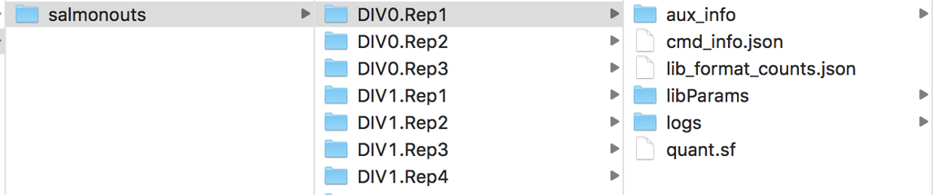

```r
#The directory where all of the sample-specific salmon subdirectories live
base_dir <- '../data/salmonouts/'

#The names of all the sample-specific salmon subdirectories
sample_ids <- c('DIVminus8.Rep1', 'DIVminus8.Rep2', 'DIVminus8.Rep3', 'DIVminus8.Rep4',
                'DIVminus4.Rep1', 'DIVminus4.Rep2', 'DIVminus4.Rep3',
                'DIV0.Rep1', 'DIV0.Rep2', 'DIV0.Rep3',
                'DIV1.Rep1', 'DIV1.Rep2', 'DIV1.Rep3', 'DIV1.Rep4',
                'DIV7.Rep1', 'DIV7.Rep2', 'DIV7.Rep3', 'DIV7.Rep4',
                'DIV16.Rep1', 'DIV16.Rep2', 'DIV16.Rep3', 'DIV16.Rep4',
                'DIV21.Rep1', 'DIV21.Rep2', 'DIV21.Rep3', 'DIV21.Rep4',
                'DIV28.Rep1', 'DIV28.Rep2', 'DIV28.Rep3', 'DIV28.Rep4')

#So what we want to do now is create paths to each quant.sf file that is in each sample_id.
#This can be done by combining the base_dir, each sample_id directory, and 'quant.sf'
#For example, the path to the first file will be data/salmonouts/DIVminus8.Rep1/quant.sf

salm_dirs <- sapply(sample_ids, function(id) file.path(base_dir, id, 'quant.sf'))
salm_dirs
```

```
##                                DIVminus8.Rep1
## "../data/salmonouts//DIVminus8.Rep1/quant.sf"
##                                DIVminus8.Rep2
## "../data/salmonouts//DIVminus8.Rep2/quant.sf"
##                                DIVminus8.Rep3
## "../data/salmonouts//DIVminus8.Rep3/quant.sf"
##                                DIVminus8.Rep4
## "../data/salmonouts//DIVminus8.Rep4/quant.sf"
##                                DIVminus4.Rep1
## "../data/salmonouts//DIVminus4.Rep1/quant.sf"
##                                DIVminus4.Rep2
## "../data/salmonouts//DIVminus4.Rep2/quant.sf"
##                                DIVminus4.Rep3
## "../data/salmonouts//DIVminus4.Rep3/quant.sf"
##                                     DIV0.Rep1
##      "../data/salmonouts//DIV0.Rep1/quant.sf"
##                                     DIV0.Rep2
##      "../data/salmonouts//DIV0.Rep2/quant.sf"
##                                     DIV0.Rep3
##      "../data/salmonouts//DIV0.Rep3/quant.sf"
##                                     DIV1.Rep1
##      "../data/salmonouts//DIV1.Rep1/quant.sf"
##                                     DIV1.Rep2
##      "../data/salmonouts//DIV1.Rep2/quant.sf"
##                                     DIV1.Rep3
##      "../data/salmonouts//DIV1.Rep3/quant.sf"
##                                     DIV1.Rep4
##      "../data/salmonouts//DIV1.Rep4/quant.sf"
##                                     DIV7.Rep1
##      "../data/salmonouts//DIV7.Rep1/quant.sf"
##                                     DIV7.Rep2
##      "../data/salmonouts//DIV7.Rep2/quant.sf"
##                                     DIV7.Rep3
##      "../data/salmonouts//DIV7.Rep3/quant.sf"
##                                     DIV7.Rep4
##      "../data/salmonouts//DIV7.Rep4/quant.sf"
##                                    DIV16.Rep1
##     "../data/salmonouts//DIV16.Rep1/quant.sf"
##                                    DIV16.Rep2
##     "../data/salmonouts//DIV16.Rep2/quant.sf"
##                                    DIV16.Rep3
##     "../data/salmonouts//DIV16.Rep3/quant.sf"
##                                    DIV16.Rep4
##     "../data/salmonouts//DIV16.Rep4/quant.sf"
##                                    DIV21.Rep1
##     "../data/salmonouts//DIV21.Rep1/quant.sf"
##                                    DIV21.Rep2
##     "../data/salmonouts//DIV21.Rep2/quant.sf"
##                                    DIV21.Rep3
##     "../data/salmonouts//DIV21.Rep3/quant.sf"
##                                    DIV21.Rep4
##     "../data/salmonouts//DIV21.Rep4/quant.sf"
##                                    DIV28.Rep1
##     "../data/salmonouts//DIV28.Rep1/quant.sf"
##                                    DIV28.Rep2
##     "../data/salmonouts//DIV28.Rep2/quant.sf"
##                                    DIV28.Rep3
##     "../data/salmonouts//DIV28.Rep3/quant.sf"
##                                    DIV28.Rep4
##     "../data/salmonouts//DIV28.Rep4/quant.sf"
```

Now we are ready to run `tximport`! `tximport` is going to want paths to all the quantification files (salm_dirs) and a table that relates transcripts to genes (t2g). Luckily, we happen to have those exact two things.

```r
txi <- tximport(salm_dirs, type = 'salmon', tx2gene = t2g, dropInfReps = TRUE, countsFromAbundance = 'lengthScaledTPM')
```

```
## reading in files with read_tsv
```

```
## 1 2 3 4 5 6 7 8 9 10 11 12 13 14 15 16 17 18 19 20 21 22 23 24 25 26 27 28 29 30
## transcripts missing from tx2gene: 602
## summarizing abundance
## summarizing counts
## summarizing length
```

Notice how we chose *lengthscaledTPM* for our abundance measurement. This is going to give us TPM values (transcripts per million) for expression in the $abundance slot. Let’s check out what we have now.

```r
tpms <- txi$abundance %>%
  as.data.frame(.) %>%
  rownames_to_column(var = 'ensembl_gene_id')

head(tpms)
```

```
##      ensembl_gene_id DIVminus8.Rep1 DIVminus8.Rep2 DIVminus8.Rep3
## 1 ENSMUSG00000000001      92.799612      93.563524      95.500337
## 2 ENSMUSG00000000003       0.000000       0.000000       0.000000
## 3 ENSMUSG00000000028      59.718765      57.981259      57.935839
## 4 ENSMUSG00000000031       0.177770       0.215726       0.320948
## 5 ENSMUSG00000000037       3.187886       2.507155       2.624140
## 6 ENSMUSG00000000049       0.000000       0.000000       0.000000
##   DIVminus8.Rep4 DIVminus4.Rep1 DIVminus4.Rep2 DIVminus4.Rep3  DIV0.Rep1
## 1     101.951963     106.634101     106.395094     109.997598 148.004511
## 2       0.000000       0.000000       0.000000       0.000000   0.000000
## 3      41.663343      45.614077      47.851930      47.516125  34.180035
## 4      36.535428       0.914481       1.402704       1.317939   7.213808
## 5       2.281871       2.196733       2.309187       2.213591   5.877237
## 6       0.000000       0.000000       0.000000       0.000000   0.000000
##    DIV0.Rep2  DIV0.Rep3  DIV1.Rep1  DIV1.Rep2  DIV1.Rep3  DIV1.Rep4  DIV7.Rep1
```

[output cut: 27 more lines]

Alright, not bad!

Let’s stop and think for a minute about what `tximport` did and the metric we are using (TPM). What does *transcripts per million* mean? Well, it means pretty much what it sounds like. For every million transcripts in the cell, X of them are this particular transcript. Importantly, this means when this TPM value was calculated from the number of *counts* a transcript received, this number had to be adjusted for both the total number of counts in the library and the length of a transcript.

If sample A had twice the number of total counts as sample B (i.e. was sequenced twice as deeply), then you would expect every transcript to have approximately twice the number of counts in sample A as it has in sample B. Similarly, if transcript X is twice as long as transcript Y, then you would expect that if they were equally expressed (i.e. the same number of transcript X and transcript Y molecules were present in the sample) that X would have approximately twice the counts that Y does. Working with expression units of TPM incorporates both of these normalizations.

So, if a TPM of X means that for every million transcripts in the sample that X of them were the transcript of interest, then the sum of TPM values across all species should equal one million, right?

Let’s check and see if that’s true.

```r
sum(tpms$DIVminus8.Rep1)
```

```
## [1] 995216.3
```

```r
sum(tpms$DIVminus8.Rep2)
```

```
## [1] 995244.1
```

```r
sum(tpms$DIVminus8.Rep3)
```

```
## [1] 995222.4
```

OK, not quite one million, but pretty darn close.

This notion that TPMs represent proportions of a whole also leads to another interesting insight into what `tximport` is doing here. If all transcripts belong to genes, then the TPM for a gene must be the sum of the TPMs of its transcripts. Can we verify that that is true?

```r
#Redefine for clarity in comparisons
tpms.genes <- tpms

#Make a new tximport object, but this time instead of giving gene expression values, give transcript expression values
#This is controlled by the `txOut` argument
txi.transcripts <- tximport(salm_dirs, type = 'salmon', tx2gene = t2g, dropInfReps = TRUE,
                            countsFromAbundance = 'lengthScaledTPM', txOut = TRUE)
```

```
## reading in files with read_tsv
```

```
## 1 2 3 4 5 6 7 8 9 10 11 12 13 14 15 16 17 18 19 20 21 22 23 24 25 26 27 28 29 30
```

```r
#Make a table of tpm values for every transcript
tpms.txs <- txi.transcripts$abundance %>%
  as.data.frame(.) %>%
  rownames_to_column(var = 'ensembl_transcript_id') %>%
  inner_join(t2g, ., by = 'ensembl_transcript_id')

head(tpms.genes)
```

```
##      ensembl_gene_id DIVminus8.Rep1 DIVminus8.Rep2 DIVminus8.Rep3
## 1 ENSMUSG00000000001      92.799612      93.563524      95.500337
## 2 ENSMUSG00000000003       0.000000       0.000000       0.000000
## 3 ENSMUSG00000000028      59.718765      57.981259      57.935839
## 4 ENSMUSG00000000031       0.177770       0.215726       0.320948
## 5 ENSMUSG00000000037       3.187886       2.507155       2.624140
## 6 ENSMUSG00000000049       0.000000       0.000000       0.000000
##   DIVminus8.Rep4 DIVminus4.Rep1 DIVminus4.Rep2 DIVminus4.Rep3  DIV0.Rep1
## 1     101.951963     106.634101     106.395094     109.997598 148.004511
## 2       0.000000       0.000000       0.000000       0.000000   0.000000
## 3      41.663343      45.614077      47.851930      47.516125  34.180035
## 4      36.535428       0.914481       1.402704       1.317939   7.213808
## 5       2.281871       2.196733       2.309187       2.213591   5.877237
## 6       0.000000       0.000000       0.000000       0.000000   0.000000
##    DIV0.Rep2  DIV0.Rep3  DIV1.Rep1  DIV1.Rep2  DIV1.Rep3  DIV1.Rep4  DIV7.Rep1
```

[output cut: 27 more lines]

```r
head(tpms.txs)
```

```
##   ensembl_transcript_id    ensembl_gene_id DIVminus8.Rep1 DIVminus8.Rep2
## 1    ENSMUST00000082423 ENSMUSG00000064372     214.839964     199.081786
## 2    ENSMUST00000082422 ENSMUSG00000064371      16.850193       6.221307
## 3    ENSMUST00000082421 ENSMUSG00000064370    1426.656406    1506.843160
## 4    ENSMUST00000082420 ENSMUSG00000064369       4.044046       7.949446
## 5    ENSMUST00000082419 ENSMUSG00000064368    1082.003939     991.205932
## 6    ENSMUST00000082418 ENSMUSG00000064367     602.098536     556.061985
##   DIVminus8.Rep3 DIVminus8.Rep4 DIVminus4.Rep1 DIVminus4.Rep2 DIVminus4.Rep3
## 1      152.87167     270.905168       85.77435     165.754533      99.895723
## 2        0.00000       3.954820       15.14097       5.262049       9.292625
## 3     1505.51196    1130.763861     3794.07442    4161.758694    3226.140151
## 4       14.04814       3.790036       50.45550      30.309400      28.992991
## 5      984.39754     864.461624     3135.55056    3332.998105    2759.071050
## 6      561.25950     391.812577     1866.89956    2027.322843    1586.511988
##    DIV0.Rep1  DIV0.Rep2  DIV0.Rep3  DIV1.Rep1  DIV1.Rep2  DIV1.Rep3  DIV1.Rep4
```

[output cut: 27 more lines]

OK so lets look at the expression of ENSMUSG00000020634 in the first sample (DIVminus8.Rep1).

```r
#Get sum of tpm values for transcripts that belong to ENSMUSG00000020634
tpms.tx.ENSMUSG00000020634 <- filter(tpms.txs, ensembl_gene_id == 'ENSMUSG00000020634')
sumoftxtpm <- sum(tpms.tx.ENSMUSG00000020634$DIVminus8.Rep1)

#Get gene level tpm value of ENSMUSG00000020634
genetpm <- filter(tpms.genes, ensembl_gene_id == 'ENSMUSG00000020634')$DIVminus8.Rep1

#Are they the same?
sumoftxtpm
```

```
## [1] 46.71414
```

```r
genetpm
```

```
## [1] 46.71414
```

# Basic RNAseq QC

OK now that we’ve got expression values for all genes, we now might want to use these expression values to learn a little bit about our samples. One simple question is

```
Are replicates similar to each other, or at least more similar to each other than to other samples?
```

If our data is worth anything at all, we would hope that differences between replicates, which are supposed to be drawn from the same condition, are smaller than differences between samples drawn from different conditions. If that’s not true, it could indicate that one replicate is very different from other replciates (in which case we might want to remove it), or that the data in general is of poor quality.

Another question is

```
How similar is each sample to every other sample?
```

In our timecourse, we might expect that samples drawn from adjacent timepoints might be more similar to each other than samples from more distant timepoints.

## Hierarchical clustering

A simple way to think about this is to simply correlate TPM values for genes between samples. For plotting purposes here, let’s plot the log(TPM) of two samples against each other. However, for the actual correlation coefficient we are going to be using the *Spearman* correlation method, which uses ranks, not absolute values. This means that whether or not you take the log will have no effect on the Spearman correlation coefficient.

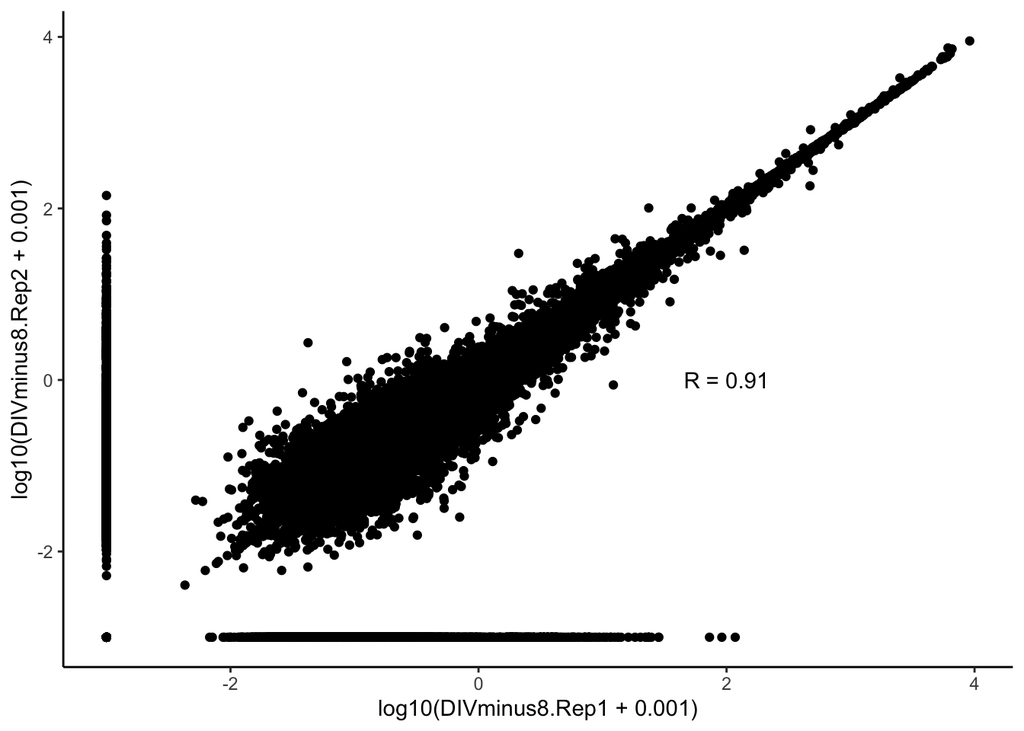

```r
#DIVminus8.Rep1 vs DIVminus8.Rep2

#Since we are plotting log TPM values, we need to add a pseudocount to all samples.
#log(0) is a problem.

#Add pseudocounts and take log within ggplot function call
r.spearman <- cor.test(tpms$DIVminus8.Rep1, tpms$DIVminus8.Rep2, method = 'spearman')$estimate[[1]]
r.spearman <- signif(r.spearman, 2)
ggplot(tpms, aes(x = log10(DIVminus8.Rep1 + 1e-3), y = log10(DIVminus8.Rep2 + 1e-3))) + geom_point() + theme_classic() +
  annotate('text', x = 2, y = 0, label = paste0('R = ', r.spearman))
```

With RNAseq data, the variance of a gene’s expression increases as the expression increases. However, using a pseudocount and taking the log of the expression value actually reverses this trend. Now, genes with the lowest expression have the most variance. Why is this a problem? Well, the genes with the most variance are going to be the ones that contribute the most to intersample differences. Ideally, we would like to therefore remove the relationship between expression and variance.

There are transformations, notably `rlog` and `vst`, that are made to deal with this, but they are best used when dealing with normalized **count** data, while here we are dealing with TPMs. We will talk about counts later, but not here.

So, for now, we will take another approach of simply using an expression threshold. Any gene that does not meet our threshold will be excluded from the analysis. Obviously where to set this threshold is a bit subjective. For now, we will set this cutoff at 1 TPM.

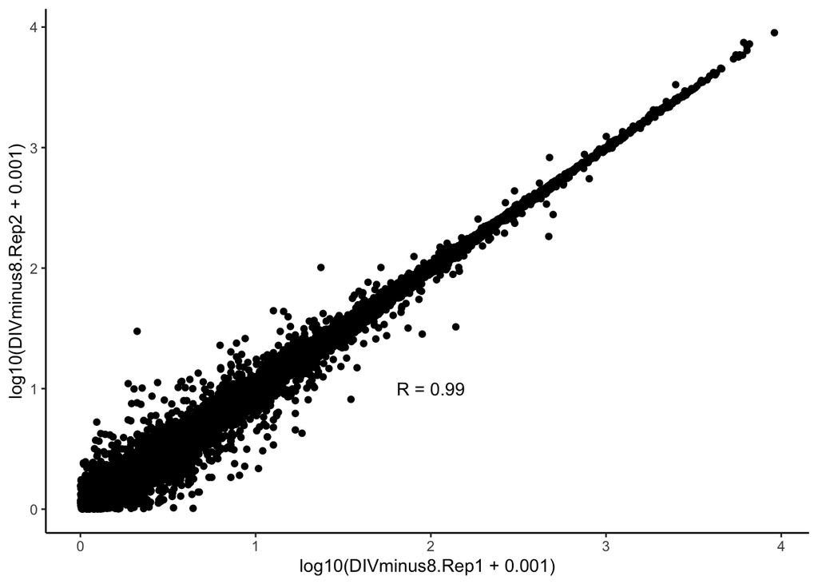

```r
#DIVminus8.Rep1 vs DIVminus8.Rep2

#Since we are plotting log TPM values, we need to add a pseudocount to all samples.
#log(0) is a problem.

#Filter for genes that have expression of at least 1 TPM in both samples
tpms.2samplecor <- dplyr::select(tpms, c(ensembl_gene_id, DIVminus8.Rep1, DIVminus8.Rep2)) %>%
  filter(., DIVminus8.Rep1 >= 1 & DIVminus8.Rep2 >= 1)

#Add pseudocounts and take log within ggplot function call
r.spearman <- cor.test(tpms.2samplecor$DIVminus8.Rep1, tpms.2samplecor$DIVminus8.Rep2, method = 'spearman')$estimate[[1]]
r.spearman <- signif(r.spearman, 2)
ggplot(tpms.2samplecor, aes(x = log10(DIVminus8.Rep1 + 1e-3), y = log10(DIVminus8.Rep2 + 1e-3))) +
  geom_point() + theme_classic() +
  annotate('text', x = 2, y = 1, label = paste0('R = ', r.spearman))
```

OK that’s two samples compared to each other, but now we want to see how **all** samples compare to **all** other samples. Before we do this we need to decide how to apply our expression cutoff across many samples. Should a gene have to meet the cutoff in only one sample? In all samples? Let’s start by saying it has to meet the cutoff in at least half of the 30 samples.

```r
#Make a new column in tpms that is the number of samples in which the value is at least 1
tpms.cutoff <- mutate(tpms, nSamples = rowSums(tpms[,2:31] > 1))%>%
  #Now filter for rows where nSamples is at least 15
  #Meaning that at least 15 samples passed the threshold
  filter(., nSamples >= 15) %>%
  #Get rid of the nSamples column
  dplyr::select(., -nSamples)

nrow(tpms)
```

```
## [1] 52346
```

```r
nrow(tpms.cutoff)
```

```
## [1] 15061
```

Now we can use the `cor` function to calculate pairwise correlations in a **matrix** of TPM values.

```r
tpms.cutoff.matrix <- dplyr::select(tpms.cutoff, -ensembl_gene_id) %>%
  as.matrix(.)

tpms.cor <- cor(tpms.cutoff.matrix, method = 'spearman')
head(tpms.cor)
```

```
##                DIVminus8.Rep1 DIVminus8.Rep2 DIVminus8.Rep3 DIVminus8.Rep4
## DIVminus8.Rep1      1.0000000      0.9874291      0.9874863      0.9656629
## DIVminus8.Rep2      0.9874291      1.0000000      0.9887704      0.9663987
## DIVminus8.Rep3      0.9874863      0.9887704      1.0000000      0.9672342
## DIVminus8.Rep4      0.9656629      0.9663987      0.9672342      1.0000000
## DIVminus4.Rep1      0.9613798      0.9618754      0.9611926      0.9386769
## DIVminus4.Rep2      0.9609581      0.9599379      0.9609036      0.9377638
##                DIVminus4.Rep1 DIVminus4.Rep2 DIVminus4.Rep3 DIV0.Rep1 DIV0.Rep2
## DIVminus8.Rep1      0.9613798      0.9609581      0.9618412 0.7926824 0.7998363
## DIVminus8.Rep2      0.9618754      0.9599379      0.9614563 0.7948024 0.8015281
## DIVminus8.Rep3      0.9611926      0.9609036      0.9613304 0.7943499 0.7994011
## DIVminus8.Rep4      0.9386769      0.9377638      0.9371555 0.7821715 0.7871162
## DIVminus4.Rep1      1.0000000      0.9874579      0.9885148 0.8292617 0.8339424
## DIVminus4.Rep2      0.9874579      1.0000000      0.9873445 0.8254047 0.8313876
##                DIV0.Rep3 DIV1.Rep1 DIV1.Rep2 DIV1.Rep3 DIV1.Rep4 DIV7.Rep1
## DIVminus8.Rep1 0.8159929 0.6966410 0.6935366 0.6960877 0.7071674 0.6029290
## DIVminus8.Rep2 0.8175660 0.6982362 0.6952722 0.6968994 0.7079007 0.6042110
## DIVminus8.Rep3 0.8171928 0.6985603 0.6942255 0.6964138 0.7070481 0.6043427
## DIVminus8.Rep4 0.8044747 0.6890168 0.6856224 0.6867085 0.6998050 0.6000377
## DIVminus4.Rep1 0.8497808 0.7343311 0.7314782 0.7321168 0.7382880 0.6157548
## DIVminus4.Rep2 0.8480450 0.7329394 0.7289499 0.7298052 0.7357465 0.6113018
##                DIV7.Rep2 DIV7.Rep3 DIV7.Rep4 DIV16.Rep1 DIV16.Rep2 DIV16.Rep3
## DIVminus8.Rep1 0.6101676 0.6032759 0.6058578  0.5026154  0.4935971  0.4945093
## DIVminus8.Rep2 0.6120526 0.6058035 0.6068240  0.5056898  0.4949182  0.4954424
## DIVminus8.Rep3 0.6125026 0.6038266 0.6059498  0.5050191  0.4942686  0.4936823
## DIVminus8.Rep4 0.6098158 0.6013481 0.6028602  0.5134745  0.5021270  0.4999295
## DIVminus4.Rep1 0.6231006 0.6157895 0.6168821  0.5079881  0.4987724  0.4976697
## DIVminus4.Rep2 0.6198181 0.6123732 0.6135401  0.5052055  0.4958990  0.4962009
##                DIV16.Rep4 DIV21.Rep1 DIV21.Rep2 DIV21.Rep3 DIV21.Rep4
## DIVminus8.Rep1  0.4942559  0.5015893  0.5011462  0.4978789  0.4978796
## DIVminus8.Rep2  0.4958286  0.5022935  0.5008581  0.4980655  0.4981462
## DIVminus8.Rep3  0.4942954  0.5014684  0.5003943  0.4987814  0.4970675
## DIVminus8.Rep4  0.5021413  0.5114995  0.5091435  0.5087365  0.5042612
## DIVminus4.Rep1  0.4994421  0.5039495  0.5012144  0.5014160  0.5015100
## DIVminus4.Rep2  0.4964639  0.5012931  0.4994238  0.4987792  0.4983438
##                DIV28.Rep1 DIV28.Rep2 DIV28.Rep3 DIV28.Rep4
## DIVminus8.Rep1  0.4936504  0.5018198  0.4936501  0.4911505
## DIVminus8.Rep2  0.4931310  0.5025217  0.4918232  0.4910483
## DIVminus8.Rep3  0.4926688  0.5028738  0.4917722  0.4917889
## DIVminus8.Rep4  0.4998905  0.5107585  0.4995558  0.4987533
## DIVminus4.Rep1  0.4985176  0.5066587  0.4975275  0.4965792
## DIVminus4.Rep2  0.4975842  0.5040839  0.4958062  0.4952847
```

Now we need to plot these and have similar samples (i.e. those that are highly correlated with each other) be clustered near to each other. We will use `pheatmap` to do this.

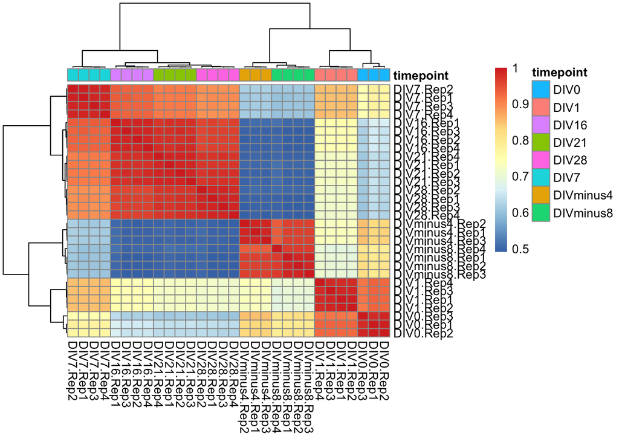

```r
library(pheatmap)

#Make a dataframe of annotations
annot <- data.frame(row.names = colnames(tpms.cor), timepoint = c(rep('DIVminus8', 4), rep('DIVminus4', 3),
                                                                  rep('DIV0', 3), rep('DIV1', 4), rep('DIV7', 4),
                                                                  rep('DIV16', 4), rep('DIV21', 4), rep('DIV28', 4)))
pheatmap(tpms.cor, annotation_col = annot)
```

This looks pretty good! There are two main points to takeaway here. First, all replicates for a given timepoint are clustering with each other. Second, you can kind of derive the order of the timepoints from the clustering. The biggest separation is between early (DIVminus8 to DIV1) and late (DIV7 to DIV28). After that you can then see finer-grained structure.

## PCA analysis

Another way to visualize the relationships and distances between samples is to use a dimensionality reduction technique called Principle Components Anlaysis or PCA. PCA works best when values are approximately normally distributed, so we will first take the log of our expression values.

With our cutoff as it is now (genes have to have expression of at least 1 TPM in half the samples), it is possible that we will have some 0 values. Taking the log of 0 might cause a problem, so we will add a pseudocount.

```r
tpms.cutoff.matrix <- dplyr::select(tpms.cutoff, -ensembl_gene_id) %>%
  as.matrix(.)

#Add pseudocount
tpms.cutoff.matrix <- tpms.cutoff.matrix + 1e-3
#Take log of values
tpms.cutoff.matrix <- log(tpms.cutoff.matrix)
```

OK now we are ready to give this matrix to R’s `prcomp` function to find principal components.

```r
#prcomp expects samples to be rownames, right now they are columns
#so we need to transpose the matrix using `t`
tpms.pca <- prcomp(t(tpms.cutoff.matrix))

#The coordinates of samples on the principle components are stored in the $x slot
#These are what we are going to use to plot
#We can also also some data about the samples here so that our plot is a little more interesting
tpms.pca.pc <- data.frame(tpms.pca$x) %>%
  mutate(., sample = colnames(tpms.cutoff.matrix)) %>%
  mutate(., timepoint = c(rep('DIVminus8', 4), rep('DIVminus4', 3),
                          rep('DIV0', 3), rep('DIV1', 4), rep('DIV7', 4),
                          rep('DIV16', 4), rep('DIV21', 4), rep('DIV28', 4)))

head(tpms.pca.pc)
```

```
##         PC1      PC2       PC3       PC4        PC5       PC6        PC7
## 1 -182.6194 61.98133 -16.17247  23.55376  -1.950990  12.28097 -42.464351
## 2 -181.8714 59.35712 -18.14529  18.21643  -1.863933  19.99230 -22.803068
## 3 -181.8522 60.18284 -16.39260  26.05008   6.091949  21.70283 -16.226412
## 4 -183.9744 81.99765 -15.05918  62.18009  24.116067 -29.56861  48.881938
## 5 -175.1073 29.05140  16.49229 -52.96375 -20.525036 -17.39873  17.522303
## 6 -176.7241 24.51892  18.62796 -52.81598  -1.918574 -21.45545   2.883239
##          PC8        PC9      PC10        PC11       PC12        PC13       PC14
## 1  17.774050 -51.925215  20.72990  23.1132943  -7.184066 -16.3835478  -5.057248
## 2   6.035596  22.957944 -31.23558  -0.1132663  15.505173  23.6769427 -27.500122
## 3  13.898250  12.871829 -15.11476 -29.4121853 -25.471930  17.0694116  29.466639
## 4 -38.315867   6.498666  16.32549   4.2875720  10.516700 -14.8036201  -2.986782
## 5  -5.815204 -23.386192 -23.81985  -7.0821272   6.244212  -0.8584383  33.959272
## 6   5.285993  18.599982  10.38979   0.1731987 -40.156108 -31.5245415 -23.869693
##          PC15       PC16       PC17        PC18       PC19       PC20      PC21
```

[output cut: 20 more lines]

```r
#We can see how much of the total variance is explained by each PC using the summary function
tpms.pca.summary <- summary(tpms.pca)$importance
head(tpms.pca.summary)
```

```
##                              PC1      PC2      PC3      PC4      PC5      PC6
## Standard deviation     115.67194 59.21000 28.73100 24.41998 21.67504 20.44568
## Proportion of Variance   0.54236  0.14211  0.03346  0.02417  0.01904  0.01694
## Cumulative Proportion    0.54236  0.68447  0.71793  0.74210  0.76114  0.77809
##                             PC7      PC8      PC9     PC10     PC11     PC12
## Standard deviation     19.76785 18.74159 18.37137 17.44536 16.99918 16.78242
## Proportion of Variance  0.01584  0.01424  0.01368  0.01234  0.01171  0.01142
## Cumulative Proportion   0.79393  0.80817  0.82185  0.83418  0.84590  0.85731
##                            PC13     PC14     PC15     PC16     PC17     PC18
## Standard deviation     16.43909 16.40473 16.12548 15.72141 15.59795 15.43861
## Proportion of Variance  0.01095  0.01091  0.01054  0.01002  0.00986  0.00966
## Cumulative Proportion   0.86827  0.87918  0.88972  0.89974  0.90960  0.91926
##                            PC19     PC20     PC21     PC22     PC23     PC24
## Standard deviation     15.08524 14.78178 14.70468 14.26197 13.81709 13.24180
## Proportion of Variance  0.00922  0.00886  0.00876  0.00824  0.00774  0.00711
## Cumulative Proportion   0.92848  0.93734  0.94611  0.95435  0.96209  0.96920
##                            PC25     PC26     PC27     PC28     PC29
## Standard deviation     13.05629 12.56717 12.19736 12.05415 11.72298
## Proportion of Variance  0.00691  0.00640  0.00603  0.00589  0.00557
## Cumulative Proportion   0.97611  0.98251  0.98854  0.99443  1.00000
##                                PC30
## Standard deviation     5.136866e-14
## Proportion of Variance 0.000000e+00
## Cumulative Proportion  1.000000e+00
```

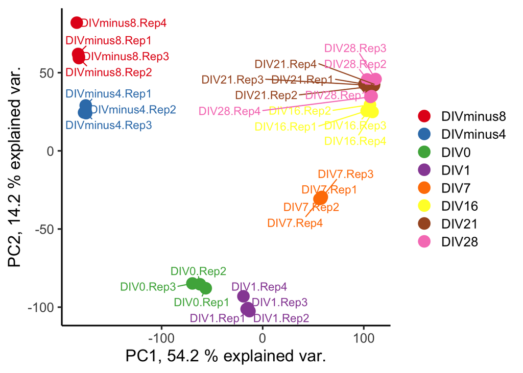

```r
#The amount of variance explained by PC1 is the second row, first column of this table
#It's given as a fraction of 1, so we multiply it by 100 to get a percentage
pc1var = round(tpms.pca.summary[2,1] * 100, 1)

#The amount of variance explained by PC2 is the second row, second column of this table
pc2var <- round(tpms.pca.summary[2,2] * 100, 1)

#Get decent looking colors.  See RColorBrewer package. This picks 8 colors from the palette Set1
colors <- brewer.pal(8, 'Set1')

#Reorder timepoints explicitly for plotting purposes
tpms.pca.pc$timepoint <- factor(tpms.pca.pc$timepoint, levels = c('DIVminus8', 'DIVminus4', 'DIV0',
                                                                  'DIV1', 'DIV7', 'DIV16', 'DIV21', 'DIV28'))

#Plot results
ggplot(tpms.pca.pc, aes(x = PC1, y = PC2, color = timepoint, label = sample)) + geom_point(size = 5)  +
  scale_color_manual(values = colors, name = '') + theme_classic(16) + xlab(paste('PC1,', pc1var, '% explained var.')) +
  ylab(paste('PC2,', pc2var, '% explained var.')) + geom_text_repel()
```

All done. With this plot you can almost trace the differentiation path. Where is the biggest jump? Which timepoints are very similar?